# I can’t Yelp but Google if customers are McHappy

**Julia Dedic/ Oct.2017**

McDonald’s is a globally recognized fast-food conglomerate that feeds about 68 million people worldwide per day. With this sheer volume of consumers, the fast-food chain is bounded by the presence of its online following. Primarily, the online reviews for McDonald’s can be found on two major websites; Google and Yelp. With this in mind, a sample of McDonald’s restaurants in Ontario will be focused on to answer the following question; do the reviews of McDonald’s vary between these two websites?

To break it down further, the primary questions of interest of this analysis are as follows:

1. Does the star rating of McDonalds vary between Google and Yelp in Ontario?
2. Are there more positive/negative comments of McDonalds in Google or Yelp reviews? What are the most common words used among the two review sites?
3. Among the three most populated cities in Ontario; Toronto, Mississauga, and Ottawa, is there a difference in star ratings of McDonald’s? Do the star ratings in each city differ by review site?

From the primary questions of interest, this analysis will ensure that some of the significant differences between Yelp’s and Google’s review systems will be outlined and in-turn, an insightful understanding of what the significant results may mean to the average McDonald’s consumer will be clarified.

**Data Collection Methodology**

The collection of data was done using Google’s and Yelp’s APIs. These APIs were used to access the published reviews on McDonald’s that consumers have posted about the various locations. The Google and Yelp reviews were collected from 54 and 50 Ontario McDonald’s locations, respectively. Then, additional searches were conducted using both websites’ API’s to collect reviews from three major Ontario cities, namely Toronto, Mississauga, and Ottawa.

**Exploratory Data Analysis**

This section will be assessing the 3 primary questions of interest.

1. Does the star rating of McDonalds vary between Google and Yelp in Ontario? After finding the average rating between Google and Yelp, notice from **Figure 1**, Google has a higher average rating comparative to Yelp with an explicit star rating of 2.93 over 2.52, respectively.

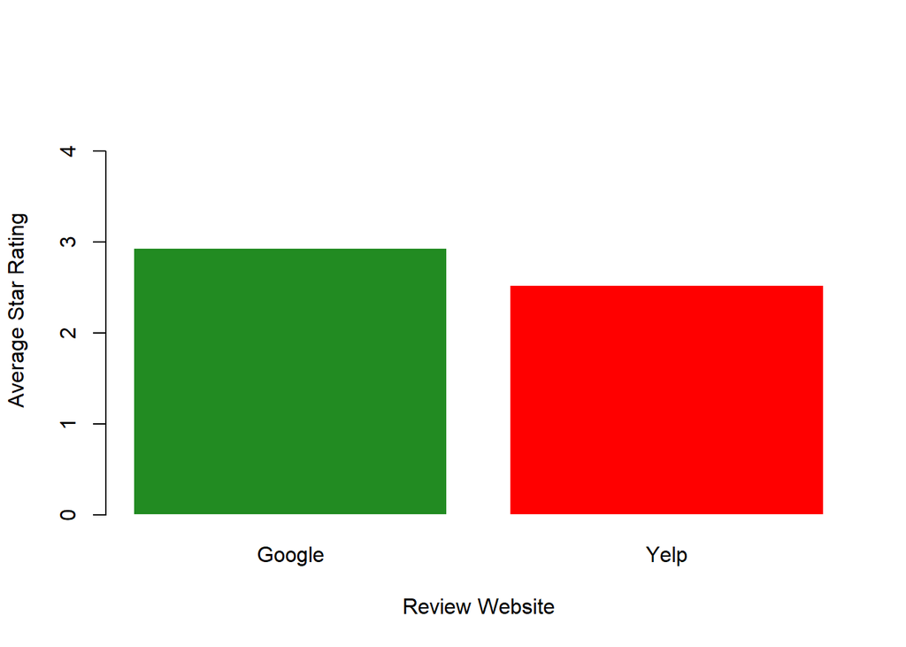

**Figure 1.** A comparative bar graph of the average star ratings found from Google (2.93/5) and Yelp (2.52/5) of McDonald’s restaurants.

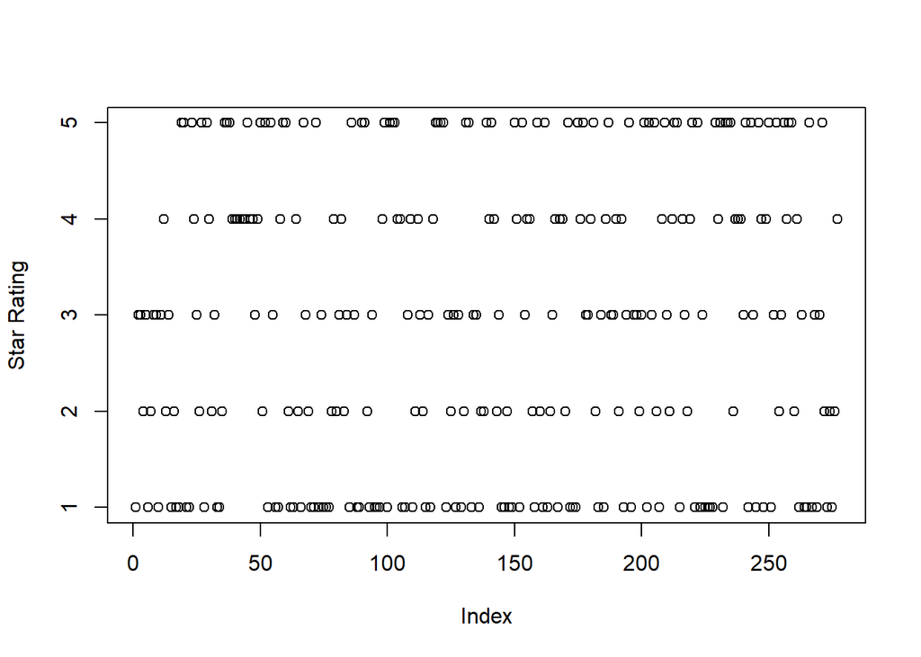

**Figure 2.** A plot of consumer star ratings for 277 Google Reviews for McDonald’s restaurants in Ontario.

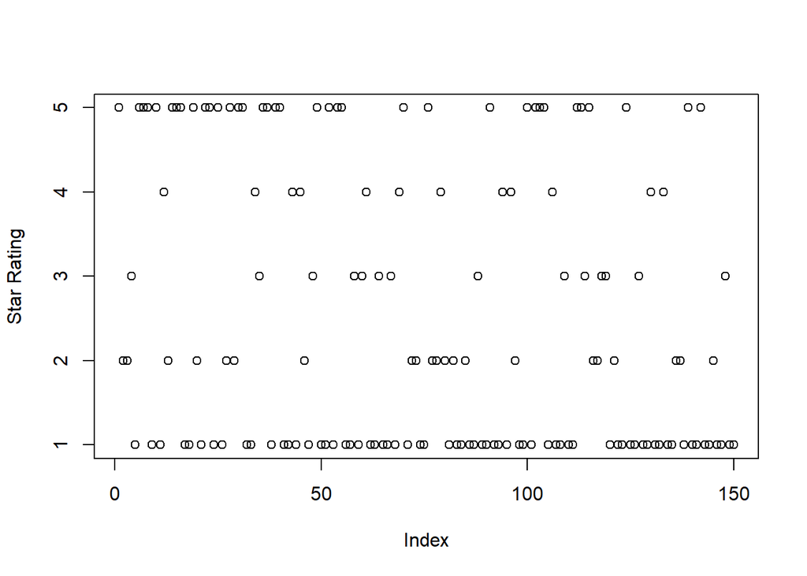

**Figure 3.** A plot of consumer star ratings for 150 Yelp Reviews for McDonald’s restaurants in Ontario.

With further statistical analysis, the standard deviation of each average star rating was determined. These values gave a verification of whether this difference based on the sample of reviews from both websites is meaningful. The standard deviation for the average star ratings for Google and Yelp are 1.54 and 1.66, respectively. This means that the average ratings for Ontario restaurants among each website are very spread. From **Table 1.**, a var-test was conducted to show that there is insufficient evidence to claim that one website has higher variation over the other. It is safe to assume that the spread among the 2 websites are the same.

**Table 1.** Variance Test between the variances of the average star ratings of McDonald’s for Google and Yelp in Ontario

| Ratio of Variation in Star Rating in Ontario (Google/Yelp) | P-value | Lower 95% CI | Upper 95% CI |
| --- | --- | --- | --- |
| 0.8578202 | 0.2768356 | 0.6427047 | 1.13118 |

Then a T-Test was conducted and shown in **Table 2.** The results below show that there is a significant difference in average star ratings of McDonald’s between each website. Google seems to provide a higher star rating on average over Yelp for locations in Ontario. Thus, when a review is seen for a particular location of McDonald’s, the average star rating tends to be higher on Google than on Yelp.

**Table 2.** Student’s T-Test between the average star ratings of McDonald’s for Google and Yelp in Ontario

| Difference in Mean Star Rating (Google - Yelp) | P-value | Lower 95% CI | Upper 95% CI |
| --- | --- | --- | --- |
| 0.4047413 | 0.0142834 | 0.0815748 | 0.7279078 |

After this portion of the analysis, it was found that the star rating of McDonald’s does vary between Google and Yelp in Ontario based the sample size of 54 and 50 McDonald’s locations collected from Google’s and Yelp’s APIs, respectively. Conclusively, Google tends to show consumers a higher star rating on average for a given location. Thus, a consumer is more likely to be persuaded positively about a particular McDonald’s location if the rating is viewed on Google over Yelp.

Although star rating is a strong indication of how consumer’s opinion will change about a given McDonald’s location, a consumer also looks up user written reviews for a McDonald’s location as well. This primarily gives the consumer a factual basis to why it may carry a particular star rating. Then by analyzing these reviews using the given APIs, comments can be categorized as positive or negative. This allows the second question to considered:

2. Are there more positive/negative comments of McDonalds in Google or Yelp reviews? What are the most common words used among the two review sites?

An analysis was conducted to compare the frequency of words used in written consumer reviews between Google and Yelp. Then a comparison was made between the associated positive and negative sentiments used between the two websites within each review.

**Figure 4.** and **Figure 5.** below are barplots for Google and Yelp displaying the frequency of the most common words found in their reviews, respectively. It can be seen that the words counted and displayed between the figures tend to be relatively the same.

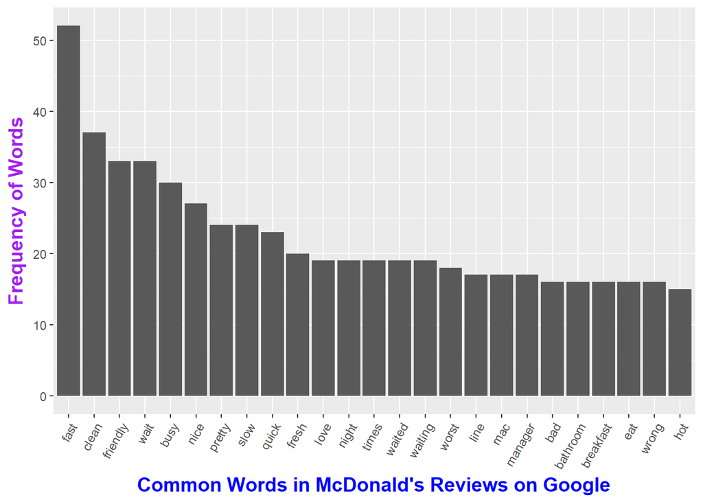

**Figure 4.** A barplot of the common words used in McDonald’s Google Reviews.

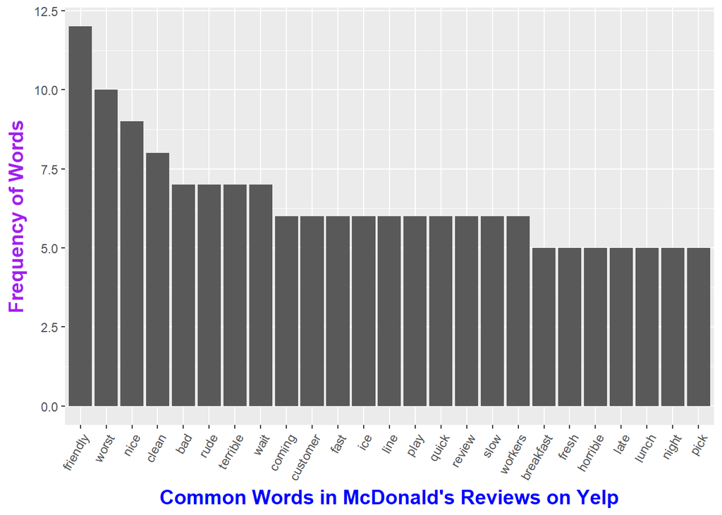

**Figure 5.** A barplot of the common words used in McDonald’s Yelp Reviews.

With this result a further to analysis was conducted to determine the sentiments of the words used in each review. The classification of words was done using the NRC Emotion Lexicon which uses a dictionary of English words and determines their association with different emotional connotation. Then the 10 most frequent emotions/sentiments were compared between Google and Yelp as a percentage of total words classified among the reviews from each website as seen in **Figure 6.** and **Figure 7.**, respectively. Finding that “positive” and “negative” sentiments were the highest among both websites, it is noteworthy to narrow in on a comparison of those classifications.

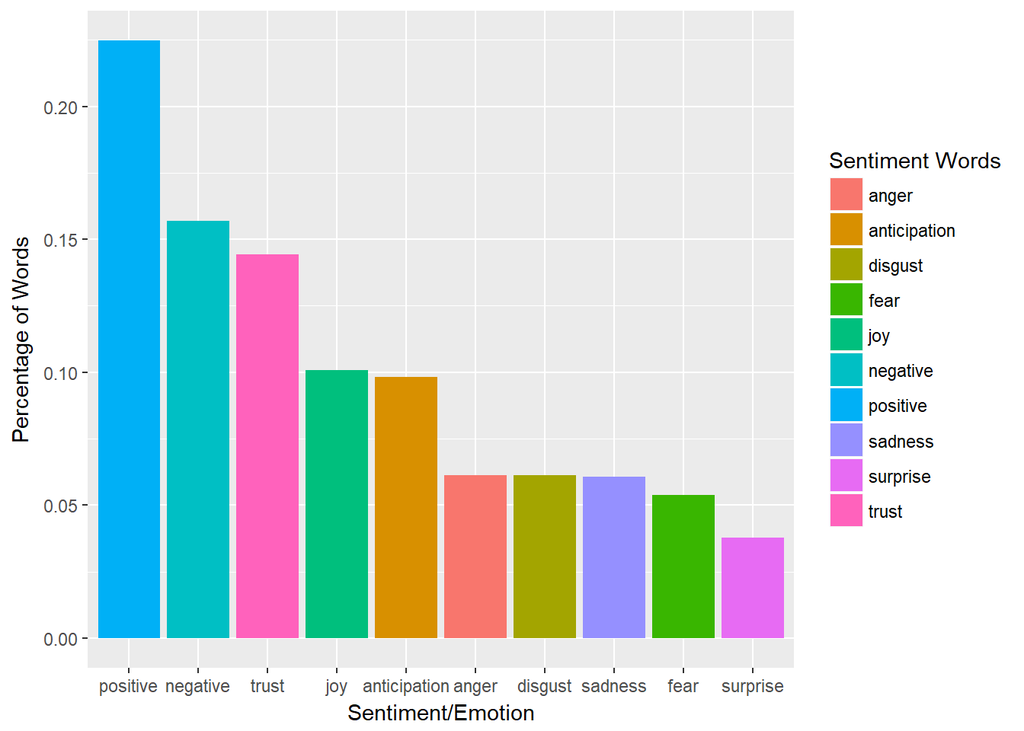

**Figure 6.** A barplot of the Percentage of sentiments/emotions in Google Reviews.

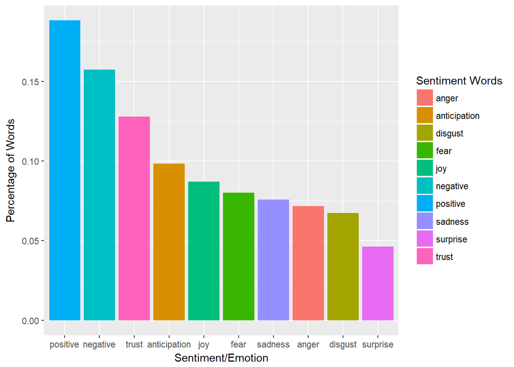

**Figure 7.** A barplot of the Percentage of sentiments/emotions in Yelp Reviews.

Then a comparison was made between the proportion of positive and negative words as a whole that were found in each of the reviews. **Figure 8.** and **Figure 9.** below are the barplot comparison of positive words and negative words, respectively, between Google and Yelp.

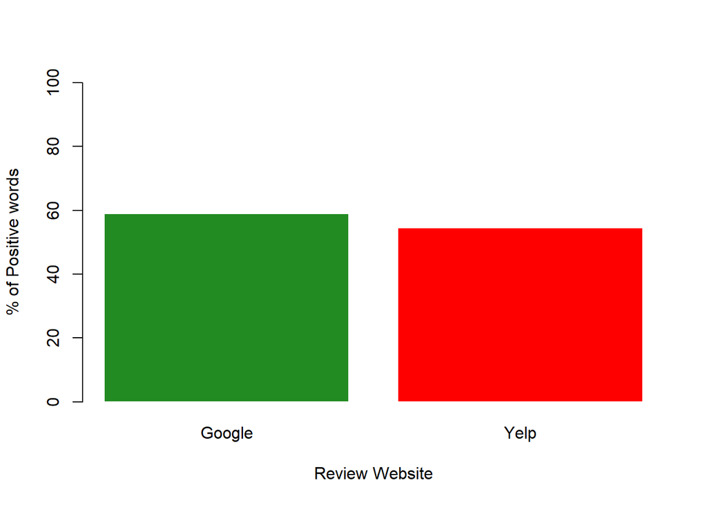

**Figure 8.** A barplot of the proportion of Positive Words between Google and Yelp.

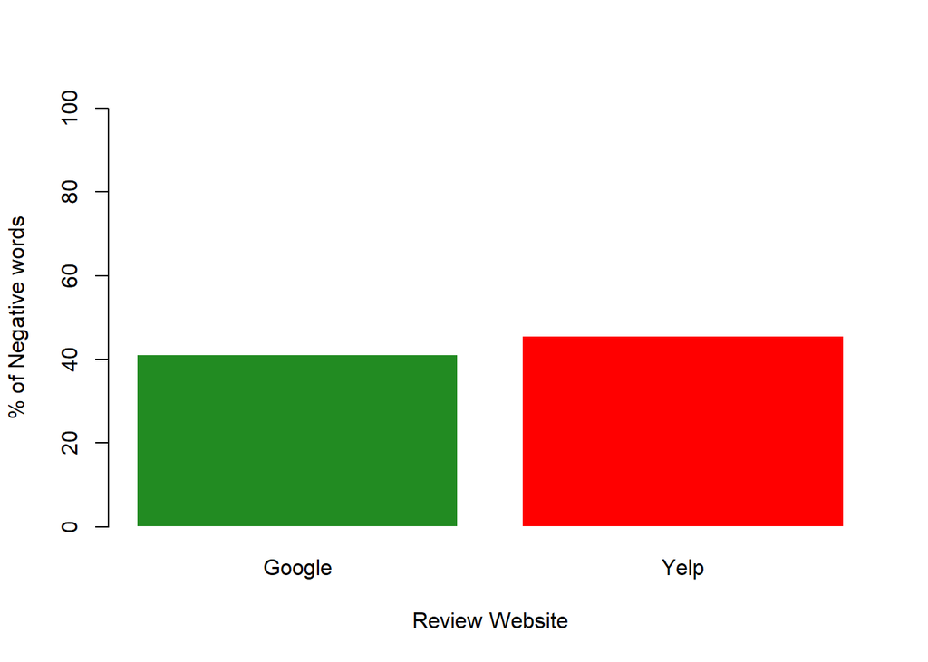

**Figure 9.** A barplot of proportion of Negative Words between Google and Yelp.

From the resulting figures, the proportion of positive and negative words between Google and Yelp are seen to vary. The number of positive words in Google and Yelp reviews were 560 (58%) and 134 (54%), respectively. Whereas the negative words in Google and Yelp reviews were 391 (41%) and 112 (45%), respectively.

This shows that it seems Google may have “nicer” reviews on average which is consistent with the previous result that Google has a higher average star rating for McDonald’s locations. However, since Yelp has about only 25% of the total number of words Google does, the proportion of positive and negative words may not be very accurate since only 150 characters per review were considered. (This will be discussed further in the limitation section.) Thus, the same conclusion can be made as previously mentioned; a consumer is more likely to be persuaded positively about a particular McDonald’s location if the rating and written reviews are viewed on Google over Yelp.

Lastly, to further analyze this result the final question of interest will be considered:

3. Among the three most populated cities in Ontario; Toronto, Mississauga, and Ottawa, is there a difference in star ratings of McDonald’s? Do the star ratings in each city differ by review site?

By assessing this question of interest, a comparison of the average star rating of McDonald’s between Google and Yelp for 3 major cities: Toronto, Mississauga, and Ottawa will be conducted. This will allow for a more concise understanding of whether Google actually has higher reviews than Yelp on average. **Figure 10.** shows the resulting means for each city within their respective website.

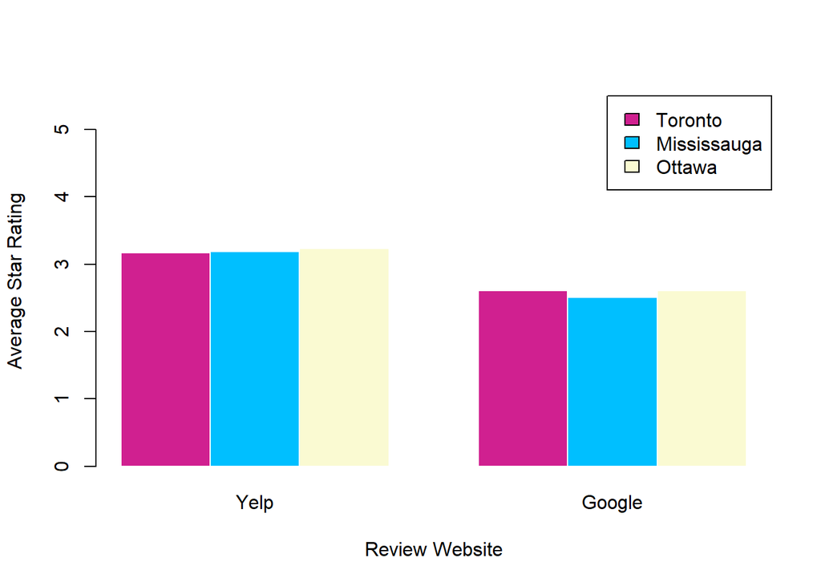

**Figure 10.** Average Star Rating of McDonald’s for Toronto, Mississauga and Ottawa  
After performing the same analysis for the 3 cities as mentioned previously, **Table 3.** and **Table 4.** display the results as follows:

**Table 3.** The average star ratings of McDonald’s for Google and Yelp between Toronto, Mississauga, and Ottawa

| Website | Toronto Mean | Mississauga Mean | Ottawa Mean |
| --- | --- | --- | --- |
| Google | 2.61 | 2.51 | 2.61 |
| Yelp | 3.166667 | 3.1875 | 3.229167 |

**Table 4.** Standard Deviations of star rating for Google and Yelp between Toronto, Mississauga, and Ottawa for the average star ratings of McDonald’s

| Website | Toronto Deviation | Mississauga Deviation | Ottawa Deviation |
| --- | --- | --- | --- |
| Google | 1.294081 | 1.527492 | 1.516875 |
| Yelp | 1.397437 | 1.282555 | 1.417813 |

Testing the variability of average star rating of cities between review sites can show whether Google or Yelp has larger variation in average star rating among the three major cities. **Table 5.** below shows the results determied from the var-tests for each of the cities. There was insufficient evidence to conlcude that there is more variation in average star ratings for each city between review sites. Therefore the spread among the two websites for each city were the same.

**Table 5.** Variance Test between the variances of the average star ratings of McDonald’s locations between Google and Yelp for Toronto, Mississauga, and Ottawa

| City | Ratio of Rating variation in (Google/Yelp) | P-value | Lower 95% CI | Upper 95% CI |
| --- | --- | --- | --- | --- |
| Toronto | 0.8575484 | 0.5058794 | 0.523646 | 1.356569 |
| Mississauga | 1.418424 | 0.183712 | 0.8450435 | 2.277939 |
| Ottawa | 1.14462 | 0.6149756 | 0.6819212 | 1.838219 |

**Table 6.** shows a T-Test between the average star ratings of McDonald’s for Google and Yelp in Toronto, Mississauga and Ottawa, assuming equal variances among the cities for each website. The results show that there is sufficient evidence to conclude that there is a difference in average star ratings between Google and Yelp for each city. It also shows that Yelp’s average star ratings for each city are higher than Google’s respectively. Implying that consumers tend to rate higher on Yelp than Google within each city. This will inherently influence consumer opinions more positively for McDonald’s reviews seen within each respective city.

**Table 6.** Student’s T-Test between the average star ratings of McDonald’s for Google and Yelp in Toronto, Mississauga and Ottawa

| City | Difference in Mean Rating (Yelp - Google) | P-value | Lower 95% CI | Upper 95% CI |
| --- | --- | --- | --- | --- |
| Toronto | 0.5566667 | 0.01436268 | 0.1125762 | 1.000757 |
| Mississauga | 0.6775 | 0.00880778 | 0.1732043 | 1.181796 |
| Ottawa | 0.6191667 | 0.01892885 | 0.1035748 | 1.134759 |

Overall, these results are particularly interesting since Google on average has a higher overall star rating for Ontario locations than Yelp. As a hypothesis, this may be due to the potential influence of the rural McDonald’s locations which may bring the Ontario’s average star rating up on Google and lowering Yelp’s overall.

**Limitations**

A few limitations of this analysis are as follows:

- The API limits from Google and Yelp limit the number of Ontario locations to 54 and 50 respectively that the reviews can be collected from. This causes the analysis to have a relatively small sample size compared to the population of all McDonald’s in Ontario. This also caused the number of reviews to be limited to 277 and 150 for Google and Yelp respectively which is again relatively small and hence, possibly not the most reflective of the population. Also, since the sample was so small analysis of the major cities within the same single search of Ontario locations was not possible. It turns out that there were only a few Ottawa and Mississauga locations captured in the Ontario searches from each website.
- Google’s API limited the number of reviews for each location to five whereas Yelp limited it to three which did not help to provide a more “accurate” average star rating among each location. This then may have distorted a bunch of individual locations star ratings and hence, could have played a big role of causing large variation both within each websites average star ratings and between websites average star ratings per city.
- The number of characters is limited to 150 per review from Yelp so comparison of words between the websites is also limited since Yelp reviews did not contain the full content of each consumer’s review. This leads to an overall lesser word count which inherently distorts the percentage of words in the reviews collected with positive/ negative sentiments.
- NRC Emotion Lexicon evaluates individual words rather than the sentiment of the entire review, meaning it is possible for the review to have more negative words but overall be positive, as an example.

**Conclusion**